# HW3

Gabby Lopez

2024-05-06

I consulted chat GPT for just almost every part of this homework - for both functions and unit tests. Max and I discussed the assignment and shared ideas, but I ended up going a different direction than what we had discussed.

1D.

```r
library(UWBiost561)
set.seed(0)
simulation <- UWBiost561::generate_partial_clique(
  n = 10,
  clique_fraction = 0.5,
  clique_edge_density = 0.9
)

adj_mat <- simulation$adj_mat
res <- UWBiost561::compute_maximal_partial_clique(
  adj_mat = adj_mat,
  alpha = 0.9
)
res
```

```
## $clique_idx
## [1] 1 2 4 5 6 7 9
##
## $edge_density
## [1] 0.9047619
```

4C. I was not able to fix my errors. I could not figure out how to get my function compute_maximal_partial_clique to run properly. I still do not really understand what a partial clique is even after researching… so I don’t know what the expected output should be.

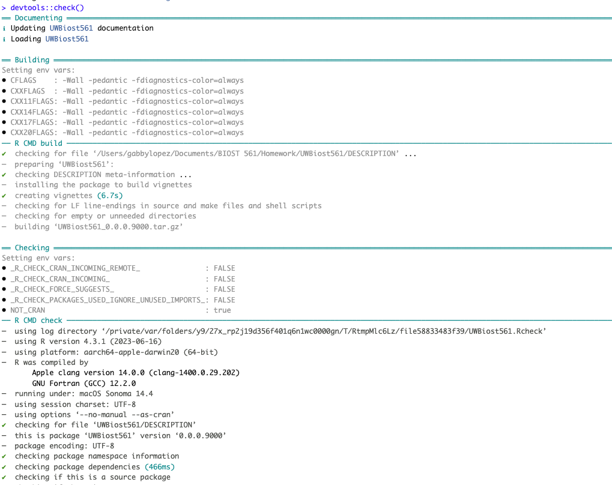

```r
knitr::include_graphics('/Users/gabbylopez/Documents/BIOST 561/Homework/check 1.png')
```

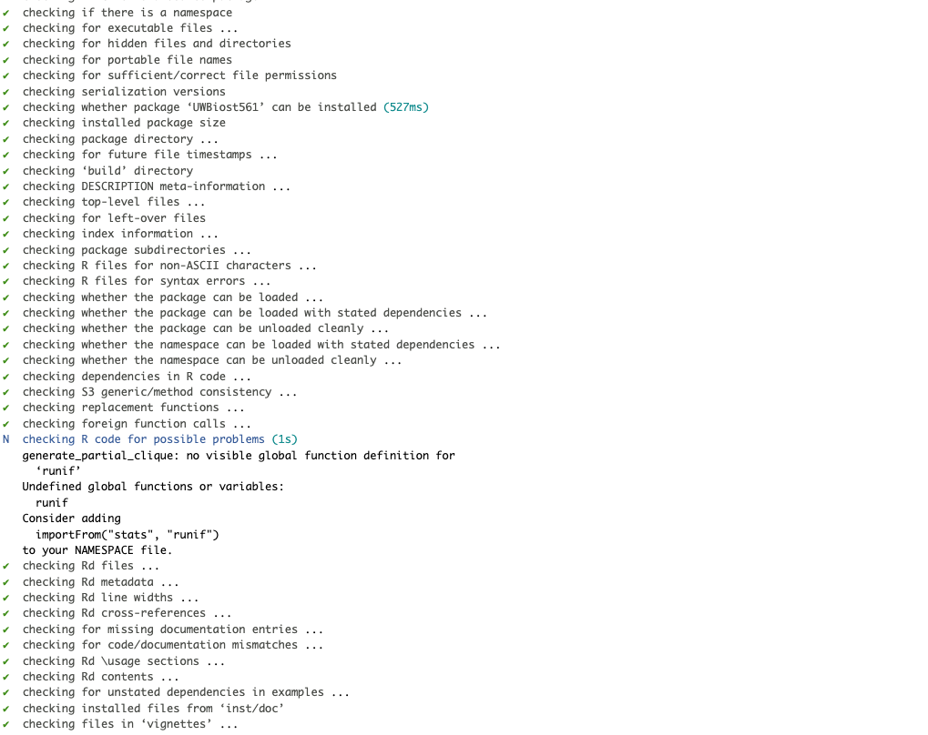

```r
knitr::include_graphics('/Users/gabbylopez/Documents/BIOST 561/Homework/check 2.png')
```

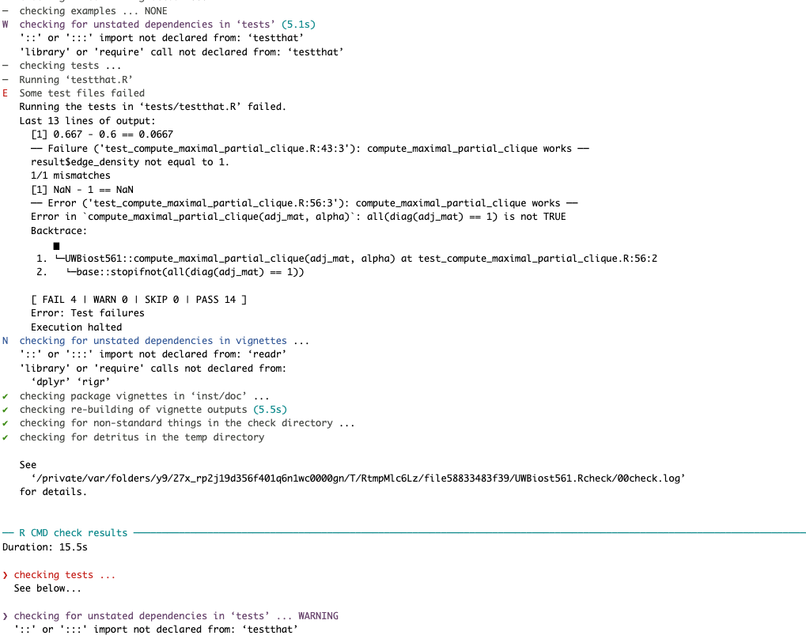

```r
knitr::include_graphics('/Users/gabbylopez/Documents/BIOST 561/Homework/check 3.png')
```

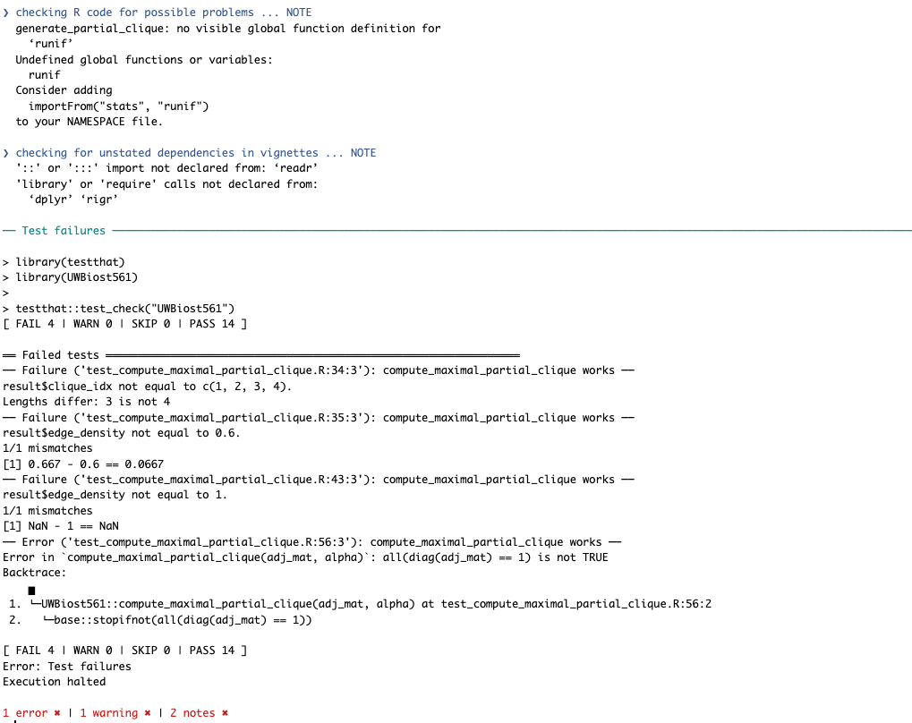

```r
knitr::include_graphics('/Users/gabbylopez/Documents/BIOST 561/Homework/check 4.png')
```

5A. I can access OpenSesame.

5B. I honestly have no idea what I want to do for this final project. I will think about it this week once I complete work for other deadlines I have.

6. I thought this homework was incredibly difficult, especially since (still after 10+ hours of work on this) I don’t understand what a clique or maximal clique is. It was hard for me to write a function for something that I didn’t understand how to compute by hand, so I had no expected output to compare it to. I like the idea of writing a function and creating/running unit tests for it - I think that is incredibly useful, but I think I would’ve gotten more from this assignment if the function we needed to write was a bit simpler.